# Sensitivity analysis of age-stratified mean imputation

# 1 Overview

## 1.1 Aims

This report aims to assess the impact of using mean-imputation at model deployment, as opposed to collecting true values.

## 1.2 Methods

To do this, we evaluate model performance when systolic blood pressure (SBP), non-HDL cholesterol (non-HDL) and body mass index (BMI) are imputed with gender-specific means calculated within five-year age bands (referred to as *age-stratified mean imputation* throughout), prior to assessing model performance. This is compared to performance when using multiple imputation, which is our closest estimate of potential true values. Model development always takes place using the multiply imputed data, and uses the same model developed in the main manuscript. What is changed in this analysis is the imputation procedure when estimating risk scores for model validation. We choose one of the stochastically imputed datasets from the multiple imputation procedure, and evalute performance solely within this dataset, due to variance in performance across the imputed datasets being minimal. The effect of using age-stratified mean imputation is evaluated for each variable (SBP, non-HDL and BMI) in isolation.

The process is as follows:

- Step 1: Take one dataset imputed using multiple imputation from the main manuscript, and the corresponding prediction model that was developed on it.
- Step 2: Estimate counterfactual survival times.
- Step 3: Evaluate performance using predictions based on the multiply imputed values
- Step 4: For each of SBP, non-HDL and BMI, evaluate performance using predictions based on age-stratified means of either SBP, non-HDL or BMI. Means for all ages are calculated within rolling five year age bands. All values are replaced with the age-stratified means, to replicate the process of using mean imputation on all individuals at deployment.
- Step 5: Repeat steps 3 and 4, within subgroups defined by the multiply imputed values of SBP, non-HDL and BMI. This is because mean imputation may on average result in well calibrated predictions, but a drop in performance among those with values further from the means.

Note steps 1 - 3 align with the analysis from the main paper. In step 5, stratified analyses are undertaken in groups based on the values of SBP, non-HDL and BMI. The values defining the groups are those from the multiple imputation. Equal width ranges were preferred to equal sized quantile groups, which would have been predominantly in the healthy range. Values from female and male cohorts were pooled to create six equally spaced groups from min to max. However, for non-HDL cholesterol, a sparse upper tail produced very small groups, so values up to 6.33mmol/L were divided into five more closely spaced ranges, and all values above 6.33 mmol/L were combined into a single group. The ranges are therefore equal in width where specified, but they are not expected to contain equal numbers of individuals.

Steps 1 - 5 were carried out separately for females and males. Entire cohort validation reports performance in the entire population. Stratified analysis reports performance within six ranges defined using the original multiply imputed values. Within each range, performance using age-stratified mean imputation is compared with performance using multiple imputation. mean-imputation values presents the age-stratified means for each variable.

## 1.3 Summary

There is minimal impact on either calibration or discrimination in the entire cohort (see Entire cohort validation). There is also minimal impact on discrimination, within subgroups defined by SBP, non-HDL and BMI values, see stratified analysis. However, we do see a worsening of calibration when using mean imputation, among individuals with SBP, non-HDL or BMI values which are at the ends of the respective distributions for each of these variables. Generally, for people with higher values of the risk factors, mean imputation results in under-prediction of risk, and for those with lower values, mean imputation results in over-prediction of risk.

# 2 Entire cohort validation

## 2.1 Metrics

Model performance metrics using multiple imputation are compared with performance after age-stratified mean imputation, in the entire cohort.

Performance in the entire validation population

| Gender | Variable | Imputation approach | ICI | E50 | E90 | Discrimination |
| --- | --- | --- | --- | --- | --- | --- |
| Female | Systolic blood pressure | Multiple imputation | 0.001 | 0.000 | 0.002 | 0.875 |
| Female | Systolic blood pressure | Age-stratified mean imputation | 0.001 | 0.000 | 0.005 | 0.874 |
| Female | Non-HDL cholesterol | Multiple imputation | 0.001 | 0.000 | 0.002 | 0.875 |
| Female | Non-HDL cholesterol | Age-stratified mean imputation | 0.001 | 0.000 | 0.003 | 0.874 |
| Female | Body mass index | Multiple imputation | 0.001 | 0.000 | 0.002 | 0.875 |
| Female | Body mass index | Age-stratified mean imputation | 0.001 | 0.000 | 0.003 | 0.875 |
| Male | Systolic blood pressure | Multiple imputation | 0.001 | 0.000 | 0.002 | 0.859 |
| Male | Systolic blood pressure | Age-stratified mean imputation | 0.002 | 0.000 | 0.007 | 0.858 |
| Male | Non-HDL cholesterol | Multiple imputation | 0.001 | 0.000 | 0.002 | 0.859 |
| Male | Non-HDL cholesterol | Age-stratified mean imputation | 0.001 | 0.000 | 0.004 | 0.857 |
| Male | Body mass index | Multiple imputation | 0.001 | 0.000 | 0.002 | 0.859 |
| Male | Body mass index | Age-stratified mean imputation | 0.001 | 0.000 | 0.003 | 0.858 |

Lower ICI, E50 and E90 indicate better calibration. Higher discrimination indicates better separation of individuals with different event times. Differences are calculated as age-stratified mean imputation minus multiple imputation.

- For **ICI, E50 and E90**, a positive difference indicates worsened calibration.
- For **discrimination**, a negative difference indicates worsened discrimination.

Difference in performance using age-stratified mean imputation as opposed to multiple imputation, in the entire population

| Gender | Variable | Difference in ICI | Difference in E50 | Difference in E90 | Difference in discrimination |
| --- | --- | --- | --- | --- | --- |
| Female | Systolic blood pressure | 0.001 | -0.000 | 0.003 | -0.001 |
| Female | Non-HDL cholesterol | 0.000 | 0.000 | 0.001 | -0.001 |
| Female | Body mass index | 0.000 | 0.000 | 0.001 | -0.000 |
| Male | Systolic blood pressure | 0.001 | -0.000 | 0.004 | -0.001 |
| Male | Non-HDL cholesterol | 0.001 | -0.000 | 0.002 | -0.001 |
| Male | Body mass index | 0.000 | -0.000 | 0.000 | -0.000 |

## 2.2 Calibration plots

Calibration curves using multiple imputation are compared with performance after age-stratified mean imputation, in the entire cohort.

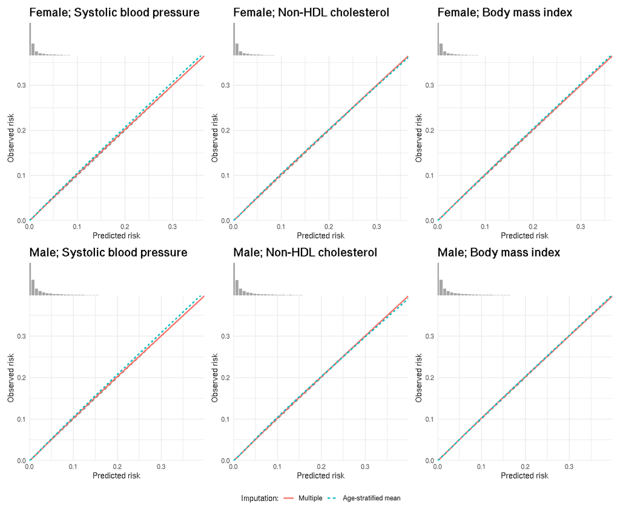

# 3 Stratified analysis

## 3.1 Metrics

Model performance metrics using multiple imputation are compared with performance after age-stratified mean imputation, in subgroups defined by ranges of SBP, non-HDL and BMI.

Calibration and discrimination within imputed-value ranges

| Gender | Variable | Range | Imputation approach | N | ICI | E50 | E90 | Discrimination |
| --- | --- | --- | --- | --- | --- | --- | --- | --- |
| Female | Systolic blood pressure | 71.00 to 94.00 | Multiple imputation | 275618 | 0.001 | 0.000 | 0.000 | 0.886 |
| Female | Systolic blood pressure | 71.00 to 94.00 | Age-stratified mean imputation | 275618 | 0.001 | 0.000 | 0.003 | 0.886 |
| Female | Systolic blood pressure | 94.00 to 117.00 | Multiple imputation | 3914335 | 0.000 | 0.000 | 0.001 | 0.880 |
| Female | Systolic blood pressure | 94.00 to 117.00 | Age-stratified mean imputation | 3914335 | 0.001 | 0.000 | 0.005 | 0.880 |
| Female | Systolic blood pressure | 117.00 to 140.00 | Multiple imputation | 4710719 | 0.001 | 0.000 | 0.002 | 0.855 |
| Female | Systolic blood pressure | 117.00 to 140.00 | Age-stratified mean imputation | 4710719 | 0.001 | 0.000 | 0.002 | 0.854 |
| Female | Systolic blood pressure | 140.00 to 163.00 | Multiple imputation | 853163 | 0.003 | 0.003 | 0.006 | 0.748 |
| Female | Systolic blood pressure | 140.00 to 163.00 | Age-stratified mean imputation | 853163 | 0.012 | 0.013 | 0.018 | 0.748 |
| Female | Systolic blood pressure | 163.00 to 186.00 | Multiple imputation | 126026 | 0.003 | 0.003 | 0.004 | 0.708 |
| Female | Systolic blood pressure | 163.00 to 186.00 | Age-stratified mean imputation | 126026 | 0.032 | 0.036 | 0.042 | 0.706 |
| Female | Systolic blood pressure | 186.00 to 209.00 | Multiple imputation | 19704 | 0.010 | 0.007 | 0.017 | 0.676 |
| Female | Systolic blood pressure | 186.00 to 209.00 | Age-stratified mean imputation | 19704 | 0.063 | 0.070 | 0.077 | 0.675 |
| Female | Non-HDL cholesterol | 0.40 to 1.59 | Multiple imputation | 155764 | 0.001 | 0.000 | 0.002 | 0.936 |
| Female | Non-HDL cholesterol | 0.40 to 1.59 | Age-stratified mean imputation | 155764 | 0.003 | 0.001 | 0.004 | 0.936 |
| Female | Non-HDL cholesterol | 1.59 to 2.77 | Multiple imputation | 2973529 | 0.000 | 0.000 | 0.001 | 0.919 |
| Female | Non-HDL cholesterol | 1.59 to 2.77 | Age-stratified mean imputation | 2973529 | 0.003 | 0.001 | 0.004 | 0.919 |
| Female | Non-HDL cholesterol | 2.77 to 3.96 | Multiple imputation | 4176770 | 0.000 | 0.000 | 0.001 | 0.880 |
| Female | Non-HDL cholesterol | 2.77 to 3.96 | Age-stratified mean imputation | 4176770 | 0.002 | 0.000 | 0.004 | 0.879 |
| Female | Non-HDL cholesterol | 3.96 to 5.14 | Multiple imputation | 1935279 | 0.001 | 0.000 | 0.004 | 0.818 |
| Female | Non-HDL cholesterol | 3.96 to 5.14 | Age-stratified mean imputation | 1935279 | 0.004 | 0.003 | 0.010 | 0.817 |
| Female | Non-HDL cholesterol | 5.14 to 6.33 | Multiple imputation | 539606 | 0.002 | 0.002 | 0.004 | 0.783 |
| Female | Non-HDL cholesterol | 5.14 to 6.33 | Age-stratified mean imputation | 539606 | 0.012 | 0.011 | 0.027 | 0.783 |
| Female | Non-HDL cholesterol | >6.33 | Multiple imputation | 118617 | 0.002 | 0.002 | 0.004 | 0.791 |
| Female | Non-HDL cholesterol | >6.33 | Age-stratified mean imputation | 118617 | 0.019 | 0.014 | 0.046 | 0.790 |
| Female | Body mass index | 18.00 to 22.83 | Multiple imputation | 3745029 | 0.000 | 0.000 | 0.000 | 0.915 |
| Female | Body mass index | 18.00 to 22.83 | Age-stratified mean imputation | 3745029 | 0.001 | 0.000 | 0.004 | 0.915 |
| Female | Body mass index | 22.83 to 27.66 | Multiple imputation | 3422949 | 0.001 | 0.000 | 0.001 | 0.873 |
| Female | Body mass index | 22.83 to 27.66 | Age-stratified mean imputation | 3422949 | 0.001 | 0.000 | 0.001 | 0.873 |
| Female | Body mass index | 27.66 to 32.50 | Multiple imputation | 1618071 | 0.001 | 0.000 | 0.004 | 0.836 |
| Female | Body mass index | 27.66 to 32.50 | Age-stratified mean imputation | 1618071 | 0.002 | 0.001 | 0.005 | 0.836 |
| Female | Body mass index | 32.50 to 37.33 | Multiple imputation | 716755 | 0.002 | 0.001 | 0.004 | 0.820 |
| Female | Body mass index | 32.50 to 37.33 | Age-stratified mean imputation | 716755 | 0.004 | 0.003 | 0.009 | 0.820 |
| Female | Body mass index | 37.33 to 42.16 | Multiple imputation | 280981 | 0.002 | 0.000 | 0.004 | 0.810 |
| Female | Body mass index | 37.33 to 42.16 | Age-stratified mean imputation | 280981 | 0.005 | 0.004 | 0.011 | 0.810 |
| Female | Body mass index | 42.16 to 46.99 | Multiple imputation | 115780 | 0.002 | 0.001 | 0.005 | 0.803 |
| Female | Body mass index | 42.16 to 46.99 | Age-stratified mean imputation | 115780 | 0.009 | 0.006 | 0.019 | 0.804 |
| Male | Systolic blood pressure | 71.00 to 94.00 | Multiple imputation | 90528 | 0.003 | 0.000 | 0.005 | 0.929 |
| Male | Systolic blood pressure | 71.00 to 94.00 | Age-stratified mean imputation | 90528 | 0.003 | 0.000 | 0.008 | 0.929 |
| Male | Systolic blood pressure | 94.00 to 117.00 | Multiple imputation | 2112826 | 0.001 | 0.000 | 0.002 | 0.893 |
| Male | Systolic blood pressure | 94.00 to 117.00 | Age-stratified mean imputation | 2112826 | 0.003 | 0.001 | 0.012 | 0.893 |
| Male | Systolic blood pressure | 117.00 to 140.00 | Multiple imputation | 5826042 | 0.001 | 0.000 | 0.002 | 0.853 |
| Male | Systolic blood pressure | 117.00 to 140.00 | Age-stratified mean imputation | 5826042 | 0.001 | 0.000 | 0.001 | 0.852 |
| Male | Systolic blood pressure | 140.00 to 163.00 | Multiple imputation | 1319280 | 0.003 | 0.002 | 0.005 | 0.786 |
| Male | Systolic blood pressure | 140.00 to 163.00 | Age-stratified mean imputation | 1319280 | 0.012 | 0.013 | 0.024 | 0.786 |
| Male | Systolic blood pressure | 163.00 to 186.00 | Multiple imputation | 144802 | 0.004 | 0.002 | 0.007 | 0.725 |
| Male | Systolic blood pressure | 163.00 to 186.00 | Age-stratified mean imputation | 144802 | 0.039 | 0.046 | 0.056 | 0.724 |
| Male | Systolic blood pressure | 186.00 to 209.00 | Multiple imputation | 17360 | 0.006 | 0.003 | 0.017 | 0.690 |
| Male | Systolic blood pressure | 186.00 to 209.00 | Age-stratified mean imputation | 17360 | 0.072 | 0.083 | 0.096 | 0.688 |
| Male | Non-HDL cholesterol | 0.40 to 1.59 | Multiple imputation | 158695 | 0.004 | 0.000 | 0.017 | 0.945 |
| Male | Non-HDL cholesterol | 0.40 to 1.59 | Age-stratified mean imputation | 158695 | 0.004 | 0.001 | 0.005 | 0.945 |
| Male | Non-HDL cholesterol | 1.59 to 2.77 | Multiple imputation | 2214110 | 0.001 | 0.000 | 0.002 | 0.930 |
| Male | Non-HDL cholesterol | 1.59 to 2.77 | Age-stratified mean imputation | 2214110 | 0.006 | 0.001 | 0.019 | 0.930 |
| Male | Non-HDL cholesterol | 2.77 to 3.96 | Multiple imputation | 3744340 | 0.001 | 0.000 | 0.001 | 0.870 |
| Male | Non-HDL cholesterol | 2.77 to 3.96 | Age-stratified mean imputation | 3744340 | 0.003 | 0.002 | 0.010 | 0.870 |
| Male | Non-HDL cholesterol | 3.96 to 5.14 | Multiple imputation | 2511395 | 0.001 | 0.001 | 0.004 | 0.814 |
| Male | Non-HDL cholesterol | 3.96 to 5.14 | Age-stratified mean imputation | 2511395 | 0.005 | 0.003 | 0.014 | 0.814 |
| Male | Non-HDL cholesterol | 5.14 to 6.33 | Multiple imputation | 747988 | 0.002 | 0.002 | 0.004 | 0.784 |
| Male | Non-HDL cholesterol | 5.14 to 6.33 | Age-stratified mean imputation | 747988 | 0.015 | 0.012 | 0.035 | 0.784 |
| Male | Non-HDL cholesterol | >6.33 | Multiple imputation | 134310 | 0.005 | 0.002 | 0.012 | 0.778 |
| Male | Non-HDL cholesterol | >6.33 | Age-stratified mean imputation | 134310 | 0.022 | 0.018 | 0.050 | 0.778 |
| Male | Body mass index | 18.00 to 22.83 | Multiple imputation | 2661325 | 0.001 | 0.000 | 0.001 | 0.917 |
| Male | Body mass index | 18.00 to 22.83 | Age-stratified mean imputation | 2661325 | 0.002 | 0.000 | 0.006 | 0.917 |
| Male | Body mass index | 22.83 to 27.66 | Multiple imputation | 4109437 | 0.001 | 0.001 | 0.002 | 0.858 |
| Male | Body mass index | 22.83 to 27.66 | Age-stratified mean imputation | 4109437 | 0.001 | 0.001 | 0.002 | 0.858 |
| Male | Body mass index | 27.66 to 32.50 | Multiple imputation | 1985137 | 0.002 | 0.001 | 0.004 | 0.812 |
| Male | Body mass index | 27.66 to 32.50 | Age-stratified mean imputation | 1985137 | 0.003 | 0.002 | 0.008 | 0.812 |
| Male | Body mass index | 32.50 to 37.33 | Multiple imputation | 559776 | 0.003 | 0.002 | 0.005 | 0.792 |
| Male | Body mass index | 32.50 to 37.33 | Age-stratified mean imputation | 559776 | 0.008 | 0.008 | 0.015 | 0.792 |
| Male | Body mass index | 37.33 to 42.16 | Multiple imputation | 146598 | 0.004 | 0.003 | 0.007 | 0.781 |
| Male | Body mass index | 37.33 to 42.16 | Age-stratified mean imputation | 146598 | 0.013 | 0.014 | 0.023 | 0.781 |
| Male | Body mass index | 42.16 to 46.99 | Multiple imputation | 48565 | 0.004 | 0.001 | 0.010 | 0.781 |
| Male | Body mass index | 42.16 to 46.99 | Age-stratified mean imputation | 48565 | 0.015 | 0.016 | 0.028 | 0.781 |

Lower ICI, E50 and E90 indicate better calibration. Higher discrimination indicates better separation of individuals with different event times. Differences are calculated as age-stratified mean imputation minus multiple imputation.

- For **ICI, E50 and E90**, a positive difference indicates worsened calibration.
- For **discrimination**, a negative difference indicates worsened discrimination.

Change in performance after age-stratified mean imputation

| Gender | Variable | Range | Difference in ICI | Difference in E50 | Difference in E90 | Difference in discrimination |
| --- | --- | --- | --- | --- | --- | --- |
| Female | Systolic blood pressure | 71.00 to 94.00 | 0.001 | 0.000 | 0.003 | 0.000 |
| Female | Systolic blood pressure | 94.00 to 117.00 | 0.001 | 0.000 | 0.004 | -0.000 |
| Female | Systolic blood pressure | 117.00 to 140.00 | 0.000 | 0.000 | -0.001 | -0.000 |
| Female | Systolic blood pressure | 140.00 to 163.00 | 0.008 | 0.010 | 0.012 | -0.001 |
| Female | Systolic blood pressure | 163.00 to 186.00 | 0.029 | 0.033 | 0.037 | -0.001 |
| Female | Systolic blood pressure | 186.00 to 209.00 | 0.053 | 0.062 | 0.060 | -0.001 |
| Female | Non-HDL cholesterol | 0.40 to 1.59 | 0.002 | 0.000 | 0.002 | -0.000 |
| Female | Non-HDL cholesterol | 1.59 to 2.77 | 0.002 | 0.000 | 0.003 | -0.000 |
| Female | Non-HDL cholesterol | 2.77 to 3.96 | 0.001 | 0.000 | 0.004 | -0.000 |
| Female | Non-HDL cholesterol | 3.96 to 5.14 | 0.003 | 0.003 | 0.006 | -0.000 |
| Female | Non-HDL cholesterol | 5.14 to 6.33 | 0.011 | 0.010 | 0.023 | -0.000 |
| Female | Non-HDL cholesterol | >6.33 | 0.016 | 0.013 | 0.042 | -0.000 |
| Female | Body mass index | 18.00 to 22.83 | 0.001 | 0.000 | 0.003 | 0.000 |
| Female | Body mass index | 22.83 to 27.66 | 0.000 | 0.000 | -0.000 | -0.000 |
| Female | Body mass index | 27.66 to 32.50 | 0.001 | 0.001 | 0.002 | -0.000 |
| Female | Body mass index | 32.50 to 37.33 | 0.002 | 0.002 | 0.005 | -0.000 |
| Female | Body mass index | 37.33 to 42.16 | 0.003 | 0.004 | 0.007 | 0.000 |
| Female | Body mass index | 42.16 to 46.99 | 0.006 | 0.005 | 0.014 | 0.000 |
| Male | Systolic blood pressure | 71.00 to 94.00 | -0.000 | 0.000 | 0.003 | 0.000 |
| Male | Systolic blood pressure | 94.00 to 117.00 | 0.003 | 0.000 | 0.011 | 0.000 |
| Male | Systolic blood pressure | 117.00 to 140.00 | -0.000 | -0.000 | -0.001 | -0.000 |
| Male | Systolic blood pressure | 140.00 to 163.00 | 0.010 | 0.011 | 0.018 | -0.000 |
| Male | Systolic blood pressure | 163.00 to 186.00 | 0.035 | 0.044 | 0.049 | -0.001 |
| Male | Systolic blood pressure | 186.00 to 209.00 | 0.066 | 0.080 | 0.078 | -0.002 |
| Male | Non-HDL cholesterol | 0.40 to 1.59 | 0.001 | 0.000 | -0.011 | 0.000 |
| Male | Non-HDL cholesterol | 1.59 to 2.77 | 0.005 | 0.000 | 0.017 | -0.000 |
| Male | Non-HDL cholesterol | 2.77 to 3.96 | 0.003 | 0.001 | 0.009 | -0.000 |
| Male | Non-HDL cholesterol | 3.96 to 5.14 | 0.004 | 0.002 | 0.010 | -0.000 |
| Male | Non-HDL cholesterol | 5.14 to 6.33 | 0.013 | 0.010 | 0.031 | -0.000 |
| Male | Non-HDL cholesterol | >6.33 | 0.017 | 0.016 | 0.038 | 0.000 |
| Male | Body mass index | 18.00 to 22.83 | 0.001 | 0.000 | 0.005 | 0.000 |
| Male | Body mass index | 22.83 to 27.66 | 0.000 | 0.000 | -0.000 | -0.000 |
| Male | Body mass index | 27.66 to 32.50 | 0.002 | 0.002 | 0.003 | -0.000 |
| Male | Body mass index | 32.50 to 37.33 | 0.005 | 0.006 | 0.010 | 0.000 |
| Male | Body mass index | 37.33 to 42.16 | 0.009 | 0.010 | 0.017 | 0.000 |
| Male | Body mass index | 42.16 to 46.99 | 0.011 | 0.014 | 0.018 | 0.000 |

## 3.2 Calibration plots

Model performance metrics using multiple imputation are compared with performance after age-stratified mean imputation, in subgroups defined by ranges of SBP, non-HDL and BMI.

### 3.2.1 Female

**Systolic blood pressure:**

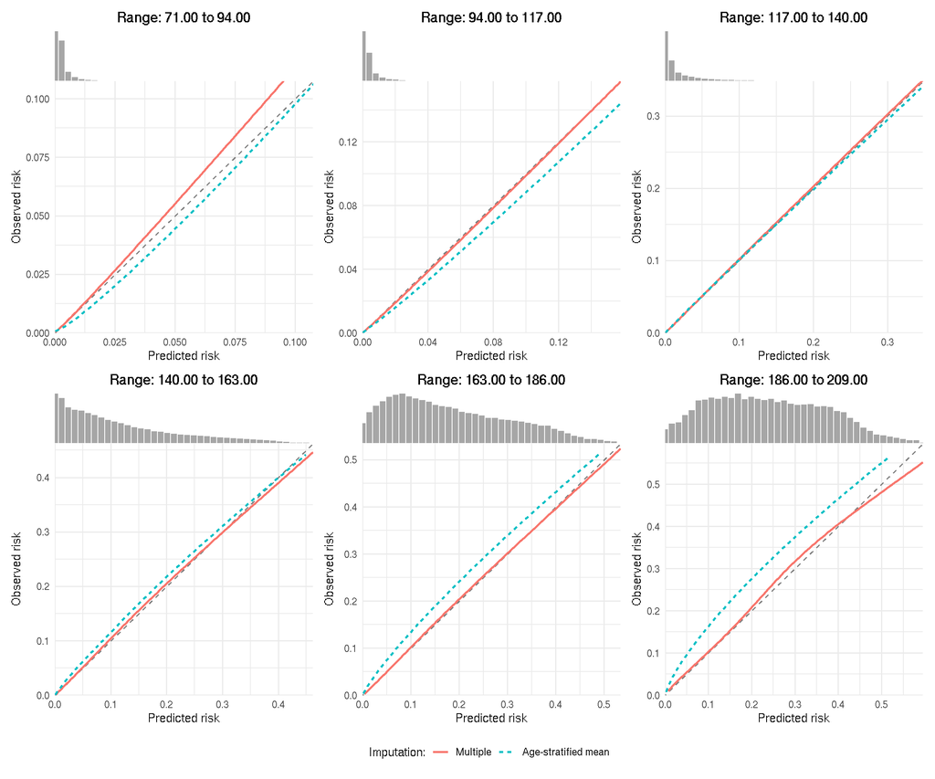

**Non-HDL cholesterol:**

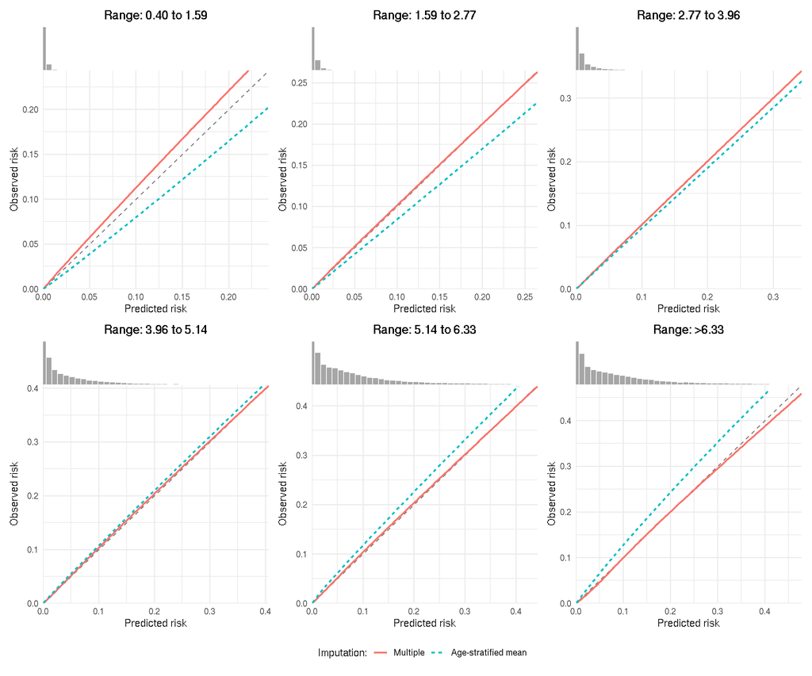

**Body mass index:**

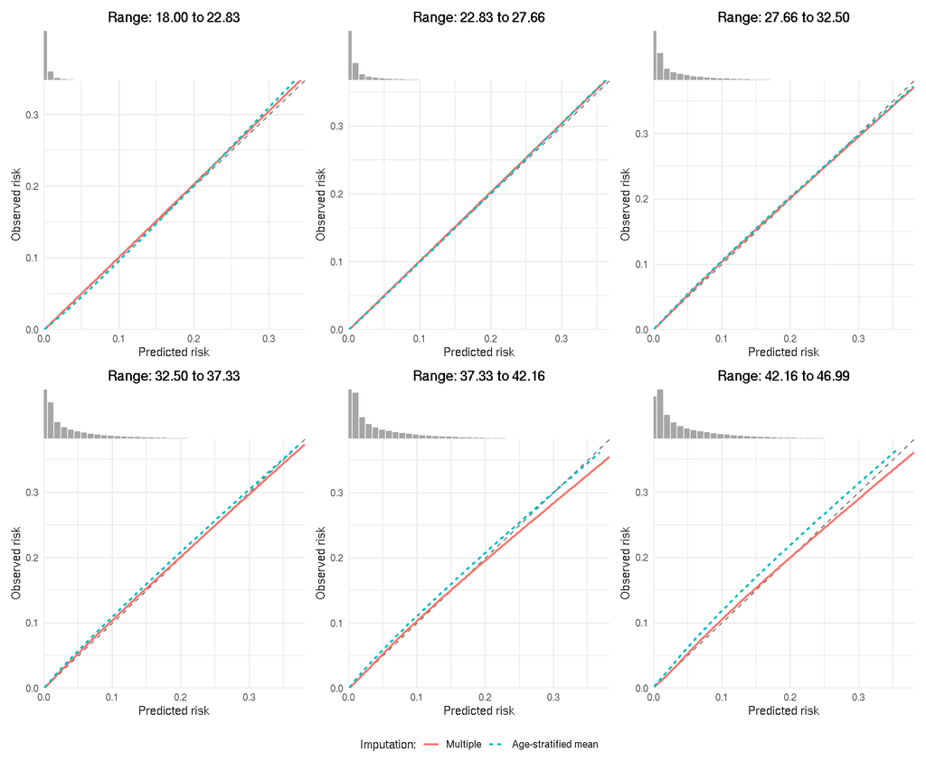

### 3.2.2 Male

**Systolic blood pressure:**

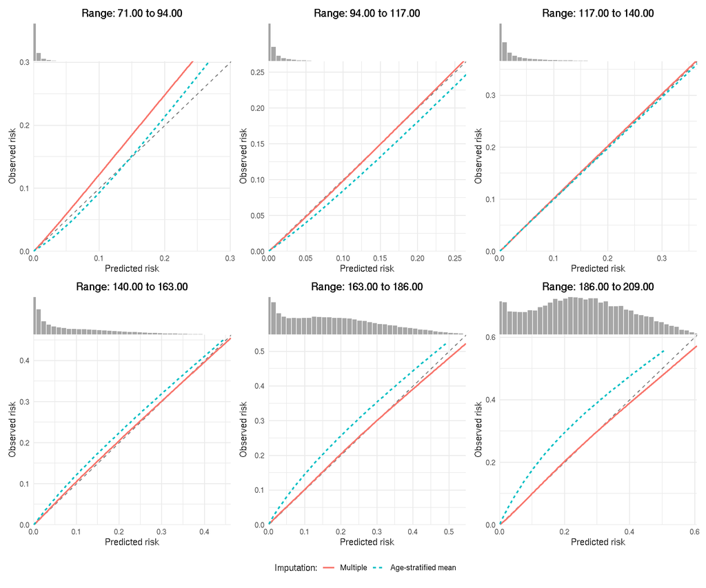

**Non-HDL cholesterol:**

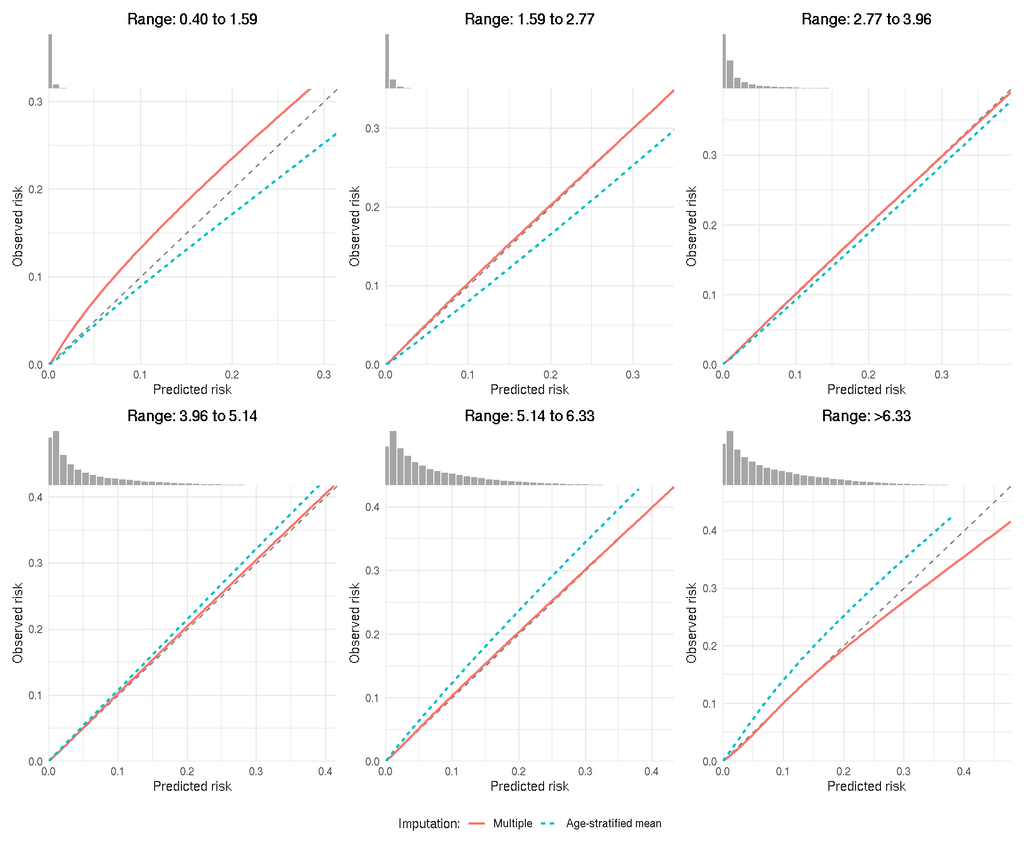

**Body mass index:**

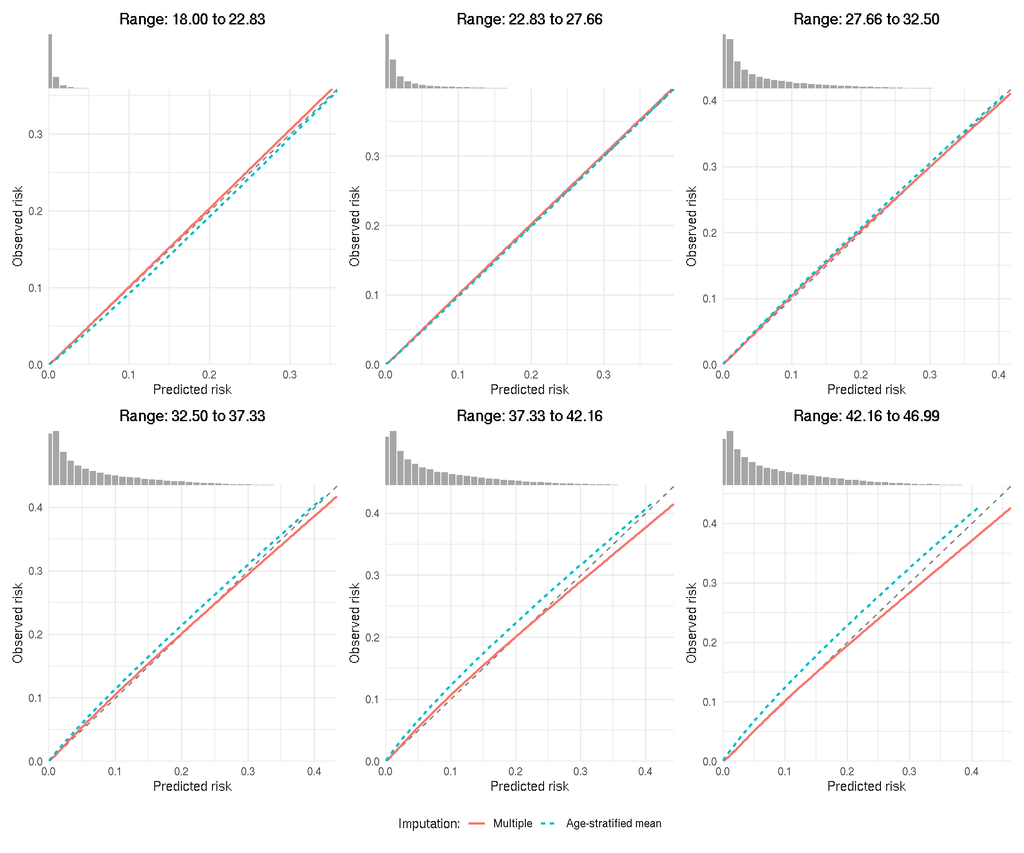

# 4 Age-stratified mean-imputation values

The following tables report the sex-specific values used to replace SBP, non-HDL cholesterol and BMI within rolling five-year age bands, used when doing the age-stratified mean imputation.

## 4.1 Female

Age-stratified mean-imputation values for females

| Gender | Variable | Age band | Mean-imputation value | N |
| --- | --- | --- | --- | --- |
| Female | Systolic blood pressure | 15-19 | 114.140 | 1144369 |
| Female | Systolic blood pressure | 16-20 | 114.382 | 1464746 |
| Female | Systolic blood pressure | 17-21 | 114.462 | 1724477 |
| Female | Systolic blood pressure | 18-22 | 114.973 | 1243304 |
| Female | Systolic blood pressure | 19-23 | 115.077 | 1448094 |
| Female | Systolic blood pressure | 20-24 | 115.027 | 1477177 |
| Female | Systolic blood pressure | 21-25 | 115.023 | 1455482 |
| Female | Systolic blood pressure | 22-26 | 115.102 | 1490187 |
| Female | Systolic blood pressure | 23-27 | 115.177 | 1502114 |
| Female | Systolic blood pressure | 24-28 | 115.266 | 1466588 |
| Female | Systolic blood pressure | 25-29 | 115.373 | 1419077 |
| Female | Systolic blood pressure | 26-30 | 115.448 | 1378496 |
| Female | Systolic blood pressure | 27-31 | 115.533 | 1331401 |
| Female | Systolic blood pressure | 28-32 | 115.652 | 1286891 |
| Female | Systolic blood pressure | 29-33 | 115.821 | 1238804 |
| Female | Systolic blood pressure | 30-34 | 116.017 | 1188071 |
| Female | Systolic blood pressure | 31-35 | 116.254 | 1134321 |
| Female | Systolic blood pressure | 32-36 | 116.564 | 1082352 |
| Female | Systolic blood pressure | 33-37 | 116.916 | 1029606 |
| Female | Systolic blood pressure | 34-38 | 117.331 | 979487 |
| Female | Systolic blood pressure | 35-39 | 117.803 | 934327 |
| Female | Systolic blood pressure | 36-40 | 118.342 | 894711 |
| Female | Systolic blood pressure | 37-41 | 118.912 | 855424 |
| Female | Systolic blood pressure | 38-42 | 119.531 | 818215 |
| Female | Systolic blood pressure | 39-43 | 120.179 | 782169 |
| Female | Systolic blood pressure | 40-44 | 120.863 | 747673 |
| Female | Systolic blood pressure | 41-45 | 121.600 | 712512 |
| Female | Systolic blood pressure | 42-46 | 122.341 | 682498 |
| Female | Systolic blood pressure | 43-47 | 123.116 | 655135 |
| Female | Systolic blood pressure | 44-48 | 123.894 | 630416 |

[output cut: 177 more lines]

## 4.2 Male

Age-stratified mean-imputation values for males

| Gender | Variable | Age band | Mean-imputation value | N |
| --- | --- | --- | --- | --- |
| Male | Systolic blood pressure | 15-19 | 120.559 | 1249843 |
| Male | Systolic blood pressure | 16-20 | 120.851 | 1512071 |
| Male | Systolic blood pressure | 17-21 | 121.057 | 1721156 |
| Male | Systolic blood pressure | 18-22 | 122.164 | 1034487 |
| Male | Systolic blood pressure | 19-23 | 122.515 | 1156383 |
| Male | Systolic blood pressure | 20-24 | 122.863 | 1158906 |
| Male | Systolic blood pressure | 21-25 | 123.209 | 1139228 |
| Male | Systolic blood pressure | 22-26 | 123.521 | 1170628 |
| Male | Systolic blood pressure | 23-27 | 123.816 | 1201948 |
| Male | Systolic blood pressure | 24-28 | 124.106 | 1212565 |
| Male | Systolic blood pressure | 25-29 | 124.387 | 1212028 |
| Male | Systolic blood pressure | 26-30 | 124.639 | 1213048 |
| Male | Systolic blood pressure | 27-31 | 124.878 | 1214775 |
| Male | Systolic blood pressure | 28-32 | 125.103 | 1213865 |
| Male | Systolic blood pressure | 29-33 | 125.331 | 1205942 |
| Male | Systolic blood pressure | 30-34 | 125.562 | 1190236 |
| Male | Systolic blood pressure | 31-35 | 125.801 | 1167185 |
| Male | Systolic blood pressure | 32-36 | 126.052 | 1139027 |
| Male | Systolic blood pressure | 33-37 | 126.313 | 1105005 |
| Male | Systolic blood pressure | 34-38 | 126.593 | 1068414 |
| Male | Systolic blood pressure | 35-39 | 126.873 | 1033028 |
| Male | Systolic blood pressure | 36-40 | 127.170 | 1000547 |
| Male | Systolic blood pressure | 37-41 | 127.456 | 967319 |
| Male | Systolic blood pressure | 38-42 | 127.765 | 934116 |
| Male | Systolic blood pressure | 39-43 | 128.077 | 899230 |
| Male | Systolic blood pressure | 40-44 | 128.407 | 864841 |
| Male | Systolic blood pressure | 41-45 | 128.747 | 826829 |
| Male | Systolic blood pressure | 42-46 | 129.119 | 790369 |
| Male | Systolic blood pressure | 43-47 | 129.481 | 755405 |
| Male | Systolic blood pressure | 44-48 | 129.858 | 721953 |

[output cut: 177 more lines]